# Workshop Week 3

Author

Affiliation

STAT5003

School of Mathematics and Statistics

# 1 Learning Outcomes

**Important**

- Understand and apply linear regression models to explore the association between two numeric variables.
  1. **Exploratory Data Analysis**: Use `summary`, `ggplot`, `plot`, `boxplot`.
  2. **Linear Regression**: Use `lm` to fit linear regression models
  3. **Model Predictions**: Use `predict` to make predictions based on the fitted model.
  4. **Communication of Results**: Develop the ability to effectively communicate the results of your analysis.

## 1.1 Melbourne house prices regression model

In this workshop, we will analyse Melbourne house prices using a dataset from [Kaggle](https://www.kaggle.com/anthonypino/melbourne-housing-market) (CC BY-NC-SA 4.0 license). We’ll focus on Brunswick, Craigieburn, and Hawthorn to identify factors affecting housing prices.

## 1.2 Exploratory Data Analysis

**Load the data & Subsetting**

Download the `"Melbourne_housing_FULL.csv"` from Canvas and read it into R. Create a new data frame `melbdata_sub` to focus on the suburbs: **Brunswick, Craigieburn, and Hawthorn**.

**Recap:** Last week, we used `subset(dataframe, Var name == "certain condition")`. In this exercise, we use `%in%` for subsetting multiple conditions.

```r
library(readr)
library(dplyr)
library(ggplot2)
library(here) # The `here` package simplifies the process of constructing file paths in R projects.
library(tidyr)
melbdata <- read.csv(here("datasets", "Melbourne_housing_FULL.csv"))
melbdata |> glimpse()

## use the baseR
melbdata_sub <- subset(melbdata, Suburb %in% c("Hawthorn", "Brunswick", "Craigieburn"))

## tidyverse syntax

melbdata_sub <- melbdata |>
  filter(Suburb %in% c("Hawthorn", "Brunswick", "Craigieburn"))
```

**Summary statistics**

Begin the analysis by generating quantitative and graphical summaries, similar to Workshop 1. For instance, calculate the average and median prices in each suburb (explore either `?tapply` or `?group_by` ). Based on the boxplot, **do house prices differ among the three suburbs?**

```r
# Calculate mean and median prices by suburb
mean_prices <- tapply(melbdata_sub$Price, melbdata_sub$Suburb, mean, na.rm = TRUE)
median_prices <- tapply(melbdata_sub$Price, melbdata_sub$Suburb, median, na.rm = TRUE)

# Display the results
mean_prices
```

```
  Brunswick Craigieburn    Hawthorn
   977988.8    566173.5   1238074.2
```

```r
median_prices
```

```
  Brunswick Craigieburn    Hawthorn
     950000      562500      750500
```

```r
## tidyverse syntax
melbdata_sub |>
  group_by(Suburb) |>
  summarise(Mean_Price = mean(Price, na.rm = TRUE), Median_price = median(Price, na.rm = TRUE))
```

```
# A tibble: 3 × 3
  Suburb      Mean_Price Median_price
  <chr>            <dbl>        <dbl>
1 Brunswick      977989.       950000
2 Craigieburn    566173.       562500
3 Hawthorn      1238074.       750500
```

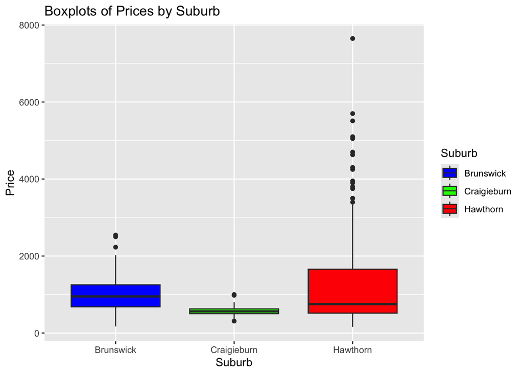

```r
# Create boxplots for each suburb using ggplot2
melbdata_sub |> ggplot(aes(x = Suburb, y = Price/1000, fill = Suburb)) +
  geom_boxplot() +
  labs(title = "Boxplots of Prices by Suburb", x = "Suburb", y = "Price") +
  scale_fill_manual(values = c("blue", "green", "red"))
```

## 1.3 Modelling

**Finding associations**

Follow Week 2’s lecture slides to examine the association between house prices (use `Price/1000` as the response) and `BuildingArea` using a simple linear regression. Justify the goodness of fit with $R^2$ and create a **scatter plot** to assess the model fit.

```r
# FORM THE LINEAR REGRESSION MODEL
lm1 <- lm(data = melbdata_sub, Price/1000 ~ BuildingArea)

# Inspect coefficients
coef(lm1)
```

```
 (Intercept) BuildingArea
  518.192115     3.800746
```

```r
lm1 |> coef() #get coefficients
```

```
 (Intercept) BuildingArea
  518.192115     3.800746
```

```r
lm1 |> fitted() |> head() #fitted values
```

```
        2         3         4         9        11        12
 928.6727  871.6615 1312.5480 1609.0062  769.0413  670.2220
```

```r
lm1 |> resid() |> head() #residuals i,e,. errors
```

```
         2          3          4          9         11         12
  97.32732  930.83851  187.45198  620.99380 -359.04135 -397.72195
```

```r
lm1 |> resid() |> mean() #check the mean of the residual is zero.
```

```
[1] 7.588188e-14
```

Consider a scatter plot of `Price` against `BuildingArea` and overlay the prediction from the linear regression model.

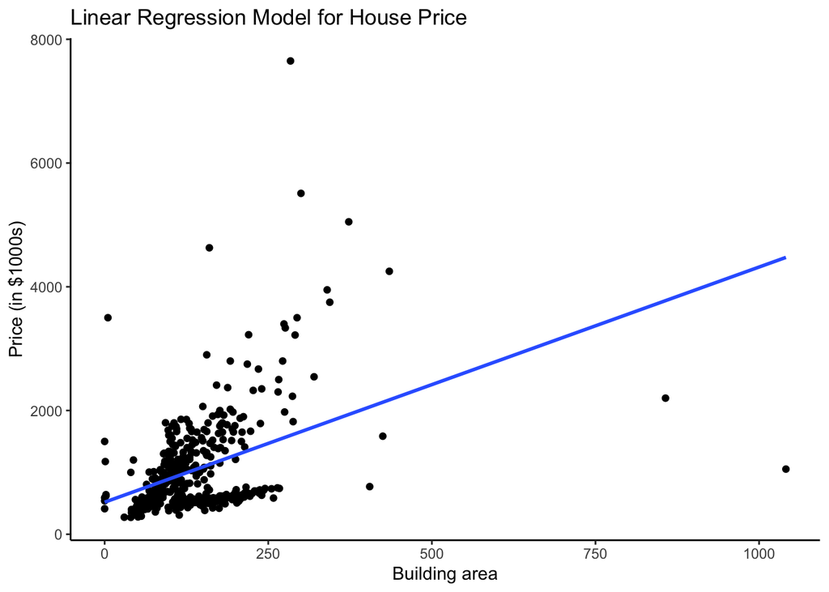

```r
melbdata_sub |> select(BuildingArea, Price) |> drop_na() |>
  ggplot(aes(x = BuildingArea, y = Price/1000)) +
  geom_point() + geom_smooth(formula = y ~ x, method = "lm", se = FALSE) +
    theme_classic() + labs(x = "Building area", y = "Price (in $1000s)", title = "Linear Regression Model for House Price")
```

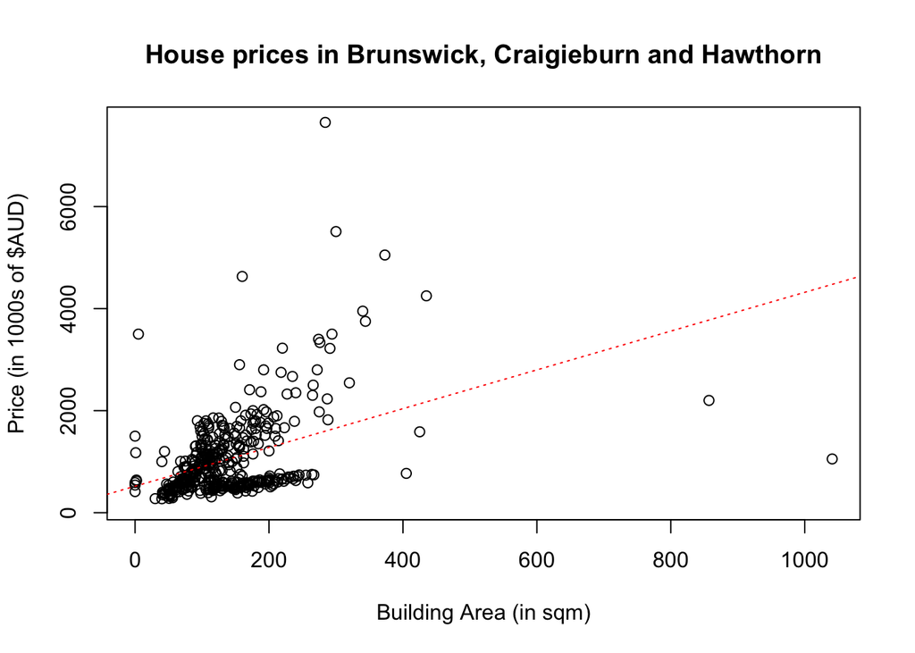

```r
# Base R to create the scatter plot

plot(Price/1000 ~ BuildingArea, data = melbdata_sub,
     main = "House prices in Brunswick, Craigieburn and Hawthorn",
     xlab = "Building Area (in sqm)", ylab = "Price (in 1000s of $AUD)")
abline(lm1, col = "red", lty = "dotted")
```

```r
r2 <- round(summary(lm1)$r.squared, 4)
r2
```

```
[1] 0.1725
```

**Comments:** There is 17% of the variation in Price explained by the linear regression on Building Area.

**Checking assumptions**

Diagnostic plots in regression analysis help with assessing the appropriateness of regression models.

- Cook’s distance shows how much fitted values change when an observation is removed.

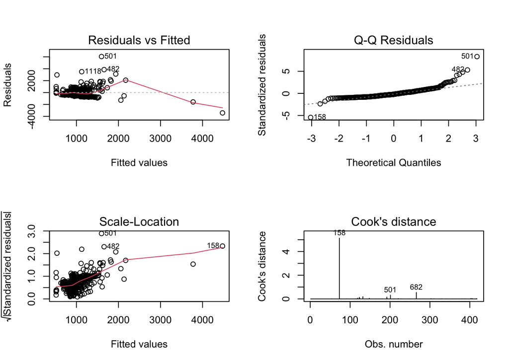

```r
## base R to create the diagnostics plots
par(mfrow = c(2, 2))
plot(lm1, which = 1:4)
```

```r
# Tidyverse way
#library(ggfortify)
#autoplot(lm1, which = 1:6, nrow = 3, ncol = 2)
```

**Removing Influential Observations**

Remove **two influential observations** and creating a new dataset `melbdata_clean`. Re-fit and re-assess the model.

```r
library(ggfortify)
library(broom)


melbdata_clean <- melbdata_sub |>
    slice(-c(158,682)) #REMOVE THE WORST TWO OUTLIERS

lm1_alt <- lm(data = melbdata_clean, Price/1000 ~ BuildingArea)
lm1_alt |> tidy() #conveniently puts summary into tibble format
```

```
# A tibble: 2 × 5
  term         estimate std.error statistic  p.value
  <chr>           <dbl>     <dbl>     <dbl>    <dbl>
1 (Intercept)    225.      75.8        2.96 3.24e- 3
2 BuildingArea     6.08     0.507     12.0  1.11e-28
```

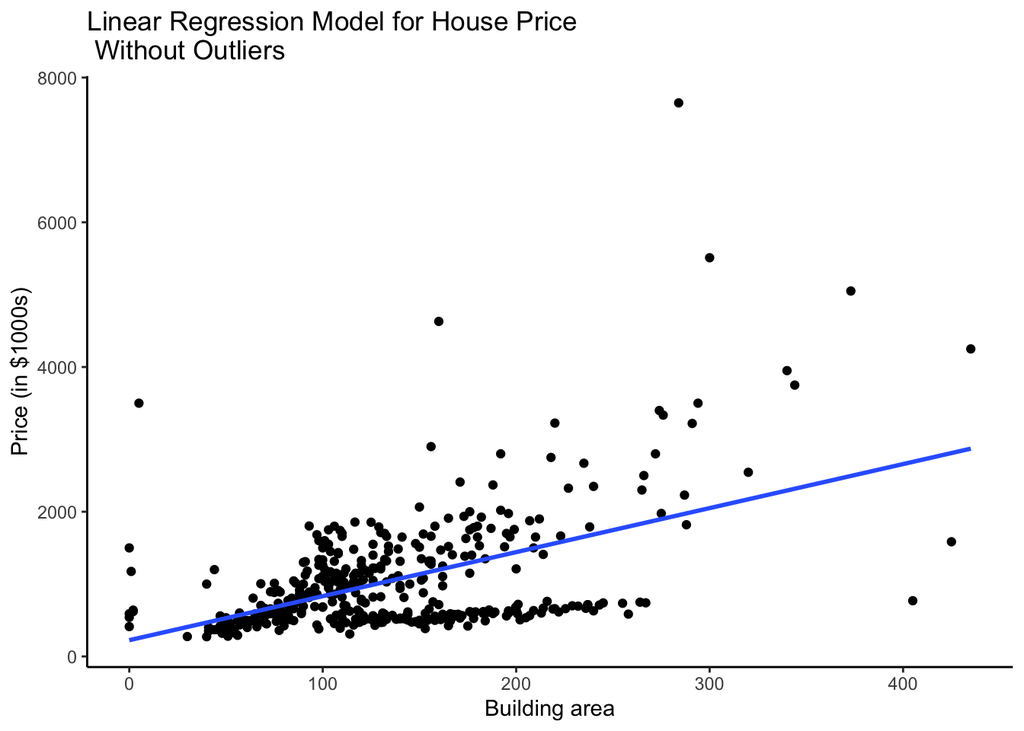

```r
melbdata_clean |> select(BuildingArea, Price) |> drop_na() |>
  ggplot(aes(x = BuildingArea, y = Price/1000)) +
    geom_point() + geom_smooth(formula = y ~ x, method = "lm", se = FALSE) +
    theme_classic() + labs(x = "Building area", y = "Price (in $1000s)", title = "Linear Regression Model for House Price \n Without Outliers")
```

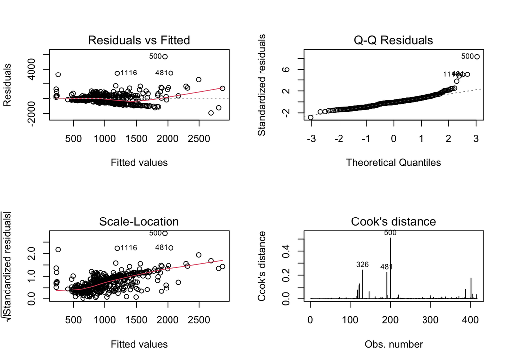

```r
## base R to create the diagnostics plots
par(mfrow = c(2, 2))
plot(lm1_alt, which = 1:4)
```

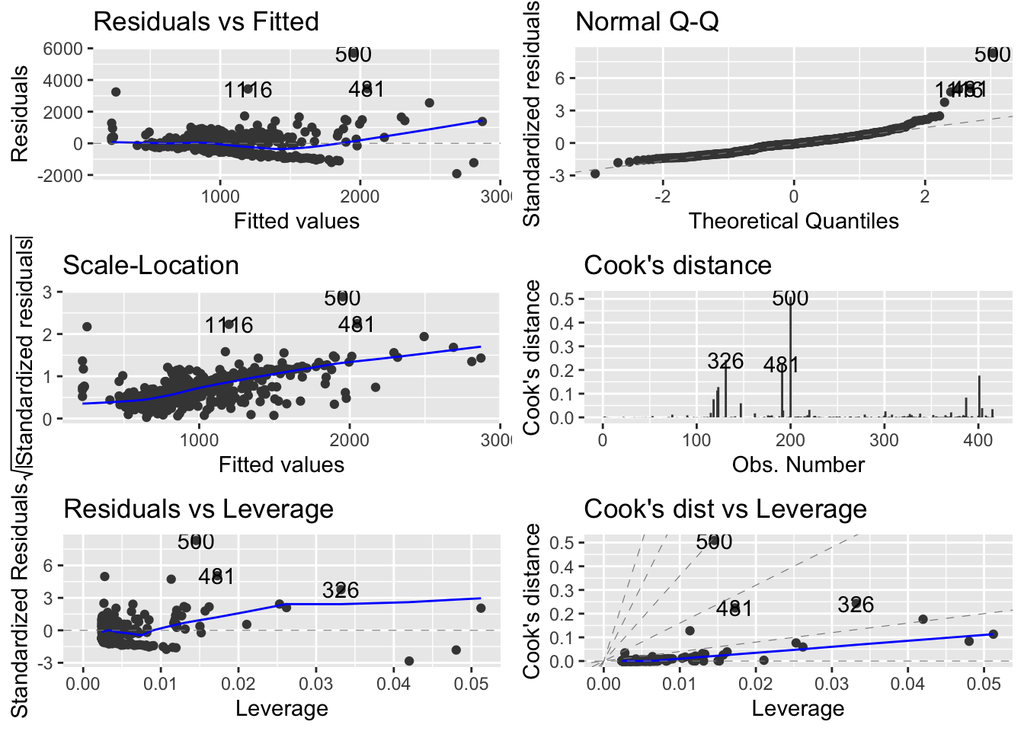

```r
## tidyverse way
autoplot(lm1_alt, which = 1:6, nrow = 3, ncol = 2)
```

## 1.4 Modelling II

**Finding association II**

*Use `melbdata_clean` to complete the rest of the workshop*

1. Examine if adding `Suburb` (categorical) as a predictor to form a multiple linear regression improves house price predictions. Comment on the regression coefficients and create a visualization.

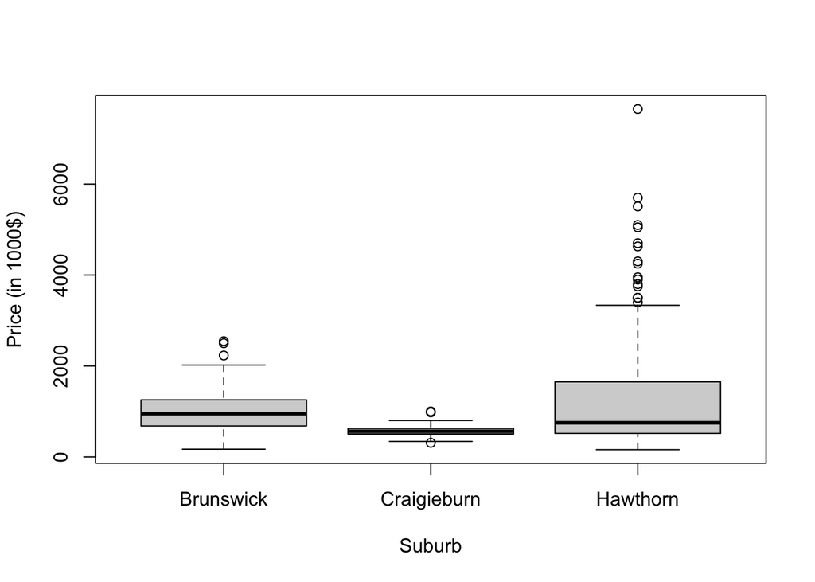

```r
## First, examine whether house prices differ significantly among different suburbs.
# Base R
boxplot(Price/1000 ~ Suburb, data = melbdata_clean, ylab = "Price (in 1000$)", xlab = "Suburb")
```

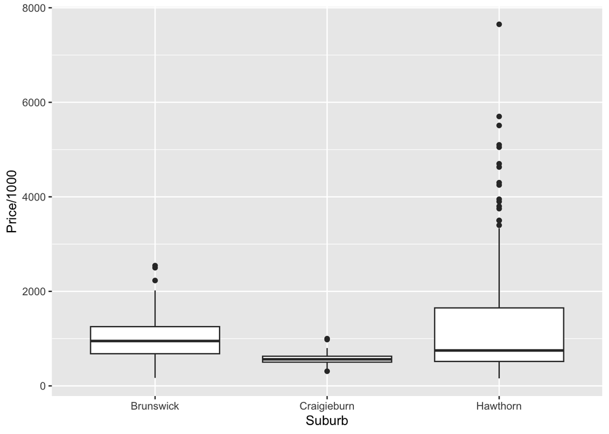

```r
# Tidyverse way

melbdata_clean |> select(Suburb, Price) |> drop_na() |>
  ggplot(aes(x = Suburb, y = Price/1000)) + geom_boxplot()
```

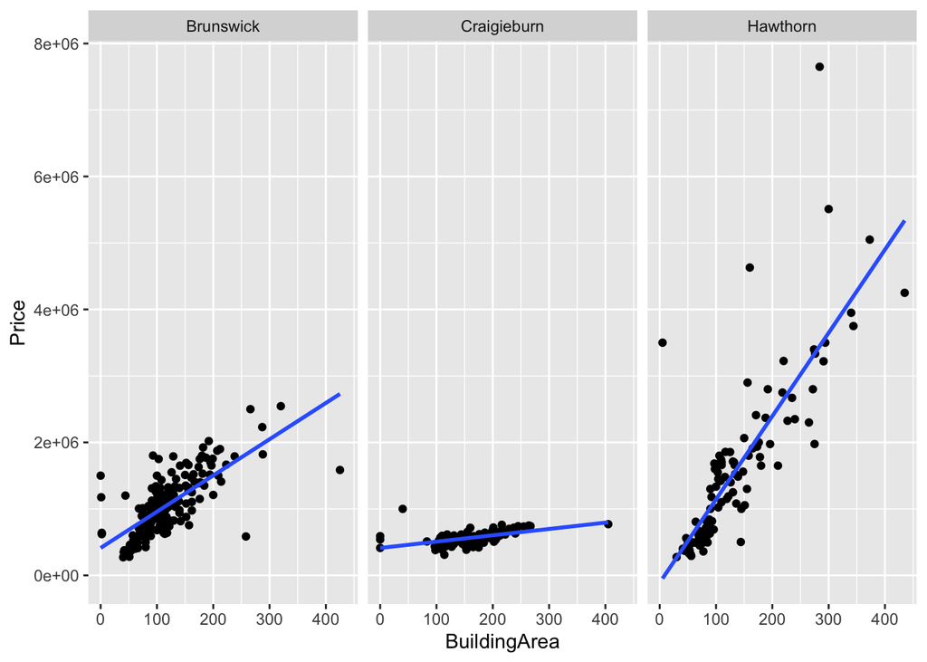

```r
# fitting the MLR
lm2 <- lm(data = melbdata_clean, Price/1000 ~ BuildingArea + Suburb)

melbdata_clean |> select(Suburb, Price, BuildingArea) |> drop_na() |>
  ggplot(aes(x = BuildingArea, y = Price)) +
  geom_point() +
  geom_smooth(formula = y ~ x, method = "lm", se = FALSE) +
  facet_wrap(~Suburb)
```

```r
r2s <- summary(lm2)$r.squared
r2s
```

```
[1] 0.5767645
```

```r
r2s <- summary(lm2)$r.squared
coef <- lm2 |>  coef()


## extract the rsquares from the simple linear reg based on the cleaned data
r2_clean <- lm1_alt |>  glance() |>  pull(r.squared)
r2_clean
```

```
[1] 0.258115
```

```r
## extract the adjusted rsquares from the MLR for a fair comparison
adj_r2 <- lm2 |>  glance() |>  pull(adj.r.squared)
adj_r2
```

```
[1] 0.5736826
```

**Commentary on Models with and without the predictor `Suburb`**

The `Suburb` predictor improves the fit of the model by increasing the $R^2$ from 0.26 to 0.58. However, the adjusted $R^2$ is more appropriate goodness of fit measure when there is more than one predictor in the model since adding another predictor will always increase the $R^2$. In this case, the comparison should be based on the adjusted $R^2$. The adjusted $R^2$ = 0.57 implying that adding `Suburb` improves the model fit.

2. There are many other variables in the data, you might consider whether adding the number of car spaces as a third predictor improve the prediction model?

```r
lm3 <- lm(data = melbdata_clean, Price ~ BuildingArea + Suburb + Car)
summary(lm3)
```

```
Call:
lm(formula = Price ~ BuildingArea + Suburb + Car, data = melbdata_clean)

Residuals:
     Min       1Q   Median       3Q      Max
-1597311  -287867   -68757   226440  4716853

Coefficients:
                   Estimate Std. Error t value Pr(>|t|)
(Intercept)         74912.2    63811.7   1.174    0.241
BuildingArea         7003.0      430.3  16.275  < 2e-16 ***
SuburbCraigieburn -882880.9    65666.4 -13.445  < 2e-16 ***
SuburbHawthorn     344935.2    62900.4   5.484 7.39e-08 ***
Car                131109.6    31594.9   4.150 4.07e-05 ***
---
Signif. codes:  0 '***' 0.001 '**' 0.01 '*' 0.05 '.' 0.1 ' ' 1

Residual standard error: 518400 on 400 degrees of freedom
  (720 observations deleted due to missingness)
Multiple R-squared:  0.5941,    Adjusted R-squared:   0.59
F-statistic: 146.4 on 4 and 400 DF,  p-value: < 2.2e-16
```

**Impact of outliers**

Model construction can be affected by unwanted variation and noise such as outliers. Using `subset` to remove outliers (building areas ≤ 5 sqm or > 300 sqm) from `melbdata_clean` and assign the new data set to `melbdata_clean2`.

**A challenge for you: In your spare time, generate the above outputs using `tidyverse` syntax**

Base R Syntax

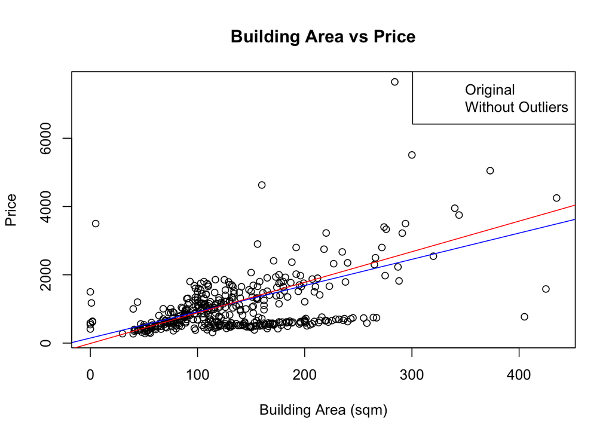

```r
# Remove outliers based on building area
melbdata_clean2 <- subset(melbdata_clean, BuildingArea > 5 & BuildingArea <= 300)

# Fit new regression line
lm4 <- lm(Price/1000 ~ BuildingArea + Suburb, data = melbdata_clean2 )

# Plot original data and regression line
plot(melbdata_clean$BuildingArea, melbdata_clean$Price/1000, main = "Building Area vs Price", xlab = "Building Area (sqm)", ylab = "Price")
abline(lm2, col = "blue")

# Add new regression line
abline(lm4, col = "red")
legend("topright", legend = c("Original", "Without Outliers"), col = c("blue", "red"), lty = 0.5)
```

```r
summary(lm4)
```

```
Call:
lm(formula = Price/1000 ~ BuildingArea + Suburb, data = melbdata_clean2)

Residuals:
    Min      1Q  Median      3Q     Max
-1716.2  -271.7   -28.3   197.8  4804.0

Coefficients:
                   Estimate Std. Error t value Pr(>|t|)
(Intercept)        -10.7494    62.0751  -0.173    0.863
BuildingArea         8.9611     0.4341  20.641  < 2e-16 ***
SuburbCraigieburn -889.7646    58.5591 -15.194  < 2e-16 ***
SuburbHawthorn     311.7892    56.0183   5.566 4.81e-08 ***
---
Signif. codes:  0 '***' 0.001 '**' 0.01 '*' 0.05 '.' 0.1 ' ' 1

Residual standard error: 460.5 on 397 degrees of freedom
  (81 observations deleted due to missingness)
Multiple R-squared:  0.6058,    Adjusted R-squared:  0.6029
F-statistic: 203.4 on 3 and 397 DF,  p-value: < 2.2e-16
```

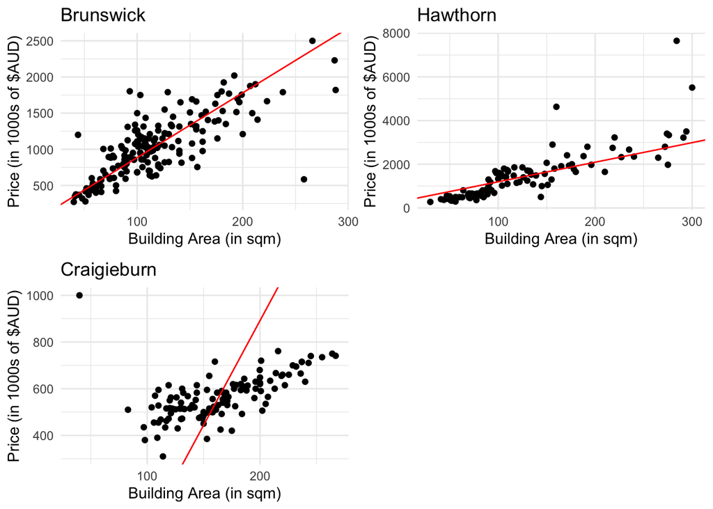

```r
## Not required but you may also see the impact of outliers on each suburb's linear fit

# Extract the coefficients from the fitted model
coefs <- lm4$coefficients

# Create a function to calculate the intercept for each suburb
calculate_intercept <- function(suburb) {
  int <- coefs[1]
  if (any(adjust.ind <- grepl(paste0(suburb, "$"), names(coefs))))
    int <- int + coefs[adjust.ind]
  return(int)
}

# Create a plot for each unique suburb
plots <- lapply(unique(melbdata_clean2$Suburb), function(suburb) {
  intercept <- calculate_intercept(suburb)
  slope <- coefs["BuildingArea"]

  ggplot(subset(melbdata_clean2, Suburb == suburb), aes(x = BuildingArea, y = Price/1000)) +
    geom_point() +
    geom_abline(intercept = intercept, slope = slope, color = "red") +
    labs(title = suburb, x = "Building Area (in sqm)", y = "Price (in 1000s of $AUD)") +
    theme_minimal()
})

# Arrange the plots in a 2x2 grid
library(gridExtra)
do.call(grid.arrange, c(plots, ncol = 2))
```

Removing the outliers does improve the fit of the model as the overall residual standard error has decreased and the goodness of fit metrics have increased to around 0.6. Also visually we can see an improved fit for Hawthorn and Brunswick. Although there still is a poor fit for Cragieburn.

**Prediction**

Using the model fitted with `BuildingArea`, `Suburb` and `Car` on the `melbdata_clean` to predict the price of a house in Hawthorn with 2 car spaces and 100 sqm in building area. What is the 95% confidence interval of your prediction value?

```r
pred <- predict(lm3, data.frame(Suburb = "Hawthorn", BuildingArea = 100, Car = 2))

predict(lm3, data.frame(Suburb = "Hawthorn", BuildingArea = 100, Car = 2), interval = "confidence")
```

```
      fit     lwr     upr
1 1382370 1273097 1491643
```

The predicted value for an average property with those features would be $1,382,370.